# Investigating a Movie Data Set

### Introduction

I am working on a movie data set collected from TMDb containing 10,000 movies with attributes such as movie budget, revenue, runtime and much more. **NOTE:** This data analysis will focus on the top 20 movies with highest revenue.

**QUESTIONS:**

1. How much did the top 20 movies cost to make?
2. How much profit did each movie make?
3. - What is the runtime of the ttop 20 movies?
   - What is the average runtime of the top 20 movies?
4. What genres are represented in the top 20?

```python
import pandas as pd
import numpy as np
import seaborn as sns
import matplotlib.pyplot as plt
%matplotlib inline
```

```python
#First we'll read and display a few lines from the csv file.
df = pd.read_csv('tmdb_movies.csv')
df.head()
```

|  | id | imdb_id | popularity | budget | revenue | original_title | cast | homepage | director | tagline | ... | overview | runtime | genres | production_companies | release_date | vote_count | vote_average | release_year | budget_adj | revenue_adj |
| --- | --- | --- | --- | --- | --- | --- | --- | --- | --- | --- | --- | --- | --- | --- | --- | --- | --- | --- | --- | --- | --- |
| 0 | 135397 | tt0369610 | 32.985763 | 150000000 | 1513528810 | Jurassic World | Chris Pratt\|Bryce Dallas Howard\|Irrfan Khan\|Vi... | http://www.jurassicworld.com/ | Colin Trevorrow | The park is open. | ... | Twenty-two years after the events of Jurassic ... | 124 | Action\|Adventure\|Science Fiction\|Thriller | Universal Studios\|Amblin Entertainment\|Legenda... | 6/9/15 | 5562 | 6.5 | 2015 | 1.379999e+08 | 1.392446e+09 |
| 1 | 76341 | tt1392190 | 28.419936 | 150000000 | 378436354 | Mad Max: Fury Road | Tom Hardy\|Charlize Theron\|Hugh Keays-Byrne\|Nic... | http://www.madmaxmovie.com/ | George Miller | What a Lovely Day. | ... | An apocalyptic story set in the furthest reach... | 120 | Action\|Adventure\|Science Fiction\|Thriller | Village Roadshow Pictures\|Kennedy Miller Produ... | 5/13/15 | 6185 | 7.1 | 2015 | 1.379999e+08 | 3.481613e+08 |
| 2 | 262500 | tt2908446 | 13.112507 | 110000000 | 295238201 | Insurgent | Shailene Woodley\|Theo James\|Kate Winslet\|Ansel... | http://www.thedivergentseries.movie/#insurgent | Robert Schwentke | One Choice Can Destroy You | ... | Beatrice Prior must confront her inner demons ... | 119 | Adventure\|Science Fiction\|Thriller | Summit Entertainment\|Mandeville Films\|Red Wago... | 3/18/15 | 2480 | 6.3 | 2015 | 1.012000e+08 | 2.716190e+08 |
| 3 | 140607 | tt2488496 | 11.173104 | 200000000 | 2068178225 | Star Wars: The Force Awakens | Harrison Ford\|Mark Hamill\|Carrie Fisher\|Adam D... | http://www.starwars.com/films/star-wars-episod... | J.J. Abrams | Every generation has a story. | ... | Thirty years after defeating the Galactic Empi... | 136 | Action\|Adventure\|Science Fiction\|Fantasy | Lucasfilm\|Truenorth Productions\|Bad Robot | 12/15/15 | 5292 | 7.5 | 2015 | 1.839999e+08 | 1.902723e+09 |
| 4 | 168259 | tt2820852 | 9.335014 | 190000000 | 1506249360 | Furious 7 | Vin Diesel\|Paul Walker\|Jason Statham\|Michelle ... | http://www.furious7.com/ | James Wan | Vengeance Hits Home | ... | Deckard Shaw seeks revenge against Dominic Tor... | 137 | Action\|Crime\|Thriller | Universal Pictures\|Original Film\|Media Rights ... | 4/1/15 | 2947 | 7.3 | 2015 | 1.747999e+08 | 1.385749e+09 |

5 rows × 21 columns

```python
#Showing the description of the dataset
df.describe()
```

|  | id | popularity | budget | revenue | runtime | vote_count | vote_average | release_year | budget_adj | revenue_adj |
| --- | --- | --- | --- | --- | --- | --- | --- | --- | --- | --- |
| count | 10866.000000 | 10866.000000 | 1.086600e+04 | 1.086600e+04 | 10866.000000 | 10866.000000 | 10866.000000 | 10866.000000 | 1.086600e+04 | 1.086600e+04 |
| mean | 66064.177434 | 0.646441 | 1.462570e+07 | 3.982332e+07 | 102.070863 | 217.389748 | 5.974922 | 2001.322658 | 1.755104e+07 | 5.136436e+07 |
| std | 92130.136561 | 1.000185 | 3.091321e+07 | 1.170035e+08 | 31.381405 | 575.619058 | 0.935142 | 12.812941 | 3.430616e+07 | 1.446325e+08 |
| min | 5.000000 | 0.000065 | 0.000000e+00 | 0.000000e+00 | 0.000000 | 10.000000 | 1.500000 | 1960.000000 | 0.000000e+00 | 0.000000e+00 |
| 25% | 10596.250000 | 0.207583 | 0.000000e+00 | 0.000000e+00 | 90.000000 | 17.000000 | 5.400000 | 1995.000000 | 0.000000e+00 | 0.000000e+00 |
| 50% | 20669.000000 | 0.383856 | 0.000000e+00 | 0.000000e+00 | 99.000000 | 38.000000 | 6.000000 | 2006.000000 | 0.000000e+00 | 0.000000e+00 |
| 75% | 75610.000000 | 0.713817 | 1.500000e+07 | 2.400000e+07 | 111.000000 | 145.750000 | 6.600000 | 2011.000000 | 2.085325e+07 | 3.369710e+07 |
| max | 417859.000000 | 32.985763 | 4.250000e+08 | 2.781506e+09 | 900.000000 | 9767.000000 | 9.200000 | 2015.000000 | 4.250000e+08 | 2.827124e+09 |

```python
#Getting information
df.info()
```

```
<class 'pandas.core.frame.DataFrame'>
RangeIndex: 10866 entries, 0 to 10865
Data columns (total 21 columns):
 #   Column                Non-Null Count  Dtype
---  ------                --------------  -----
 0   id                    10866 non-null  int64
 1   imdb_id               10856 non-null  object
 2   popularity            10866 non-null  float64
 3   budget                10866 non-null  int64
 4   revenue               10866 non-null  int64
 5   original_title        10866 non-null  object
 6   cast                  10790 non-null  object
 7   homepage              2936 non-null   object
 8   director              10822 non-null  object
 9   tagline               8042 non-null   object
 10  keywords              9373 non-null   object
 11  overview              10862 non-null  object
 12  runtime               10866 non-null  int64
 13  genres                10843 non-null  object
 14  production_companies  9836 non-null   object
 15  release_date          10866 non-null  object
 16  vote_count            10866 non-null  int64
 17  vote_average          10866 non-null  float64
 18  release_year          10866 non-null  int64
 19  budget_adj            10866 non-null  float64
 20  revenue_adj           10866 non-null  float64
dtypes: float64(4), int64(6), object(11)
memory usage: 1.7+ MB
```

```python
#After displaying information of the complete data set, I would like to keep only
#the columns that would be needed to answer the questions above by dropping the rest of the columns.

df2 = df.drop(columns = ['id','imdb_id','popularity','cast','homepage','tagline','keywords','overview','vote_count',
                         'budget_adj','revenue_adj'])
```

```python
#Now that the unwanted columns have been dropped, I will display the top 20 movies based on revenue.

df2.nlargest(n=20, columns=['revenue'], keep='all')
```

|  | budget | revenue | original_title | director | runtime | genres | production_companies | release_date | vote_average | release_year |
| --- | --- | --- | --- | --- | --- | --- | --- | --- | --- | --- |
| 1386 | 237000000 | 2781505847 | Avatar | James Cameron | 162 | Action\|Adventure\|Fantasy\|Science Fiction | Ingenious Film Partners\|Twentieth Century Fox ... | 12/10/09 | 7.1 | 2009 |
| 3 | 200000000 | 2068178225 | Star Wars: The Force Awakens | J.J. Abrams | 136 | Action\|Adventure\|Science Fiction\|Fantasy | Lucasfilm\|Truenorth Productions\|Bad Robot | 12/15/15 | 7.5 | 2015 |
| 5231 | 200000000 | 1845034188 | Titanic | James Cameron | 194 | Drama\|Romance\|Thriller | Paramount Pictures\|Twentieth Century Fox Film ... | 11/18/97 | 7.3 | 1997 |
| 4361 | 220000000 | 1519557910 | The Avengers | Joss Whedon | 143 | Science Fiction\|Action\|Adventure | Marvel Studios | 4/25/12 | 7.3 | 2012 |
| 0 | 150000000 | 1513528810 | Jurassic World | Colin Trevorrow | 124 | Action\|Adventure\|Science Fiction\|Thriller | Universal Studios\|Amblin Entertainment\|Legenda... | 6/9/15 | 6.5 | 2015 |
| 4 | 190000000 | 1506249360 | Furious 7 | James Wan | 137 | Action\|Crime\|Thriller | Universal Pictures\|Original Film\|Media Rights ... | 4/1/15 | 7.3 | 2015 |
| 14 | 280000000 | 1405035767 | Avengers: Age of Ultron | Joss Whedon | 141 | Action\|Adventure\|Science Fiction | Marvel Studios\|Prime Focus\|Revolution Sun Studios | 4/22/15 | 7.4 | 2015 |
| 3374 | 125000000 | 1327817822 | Harry Potter and the Deathly Hallows: Part 2 | David Yates | 130 | Adventure\|Family\|Fantasy | Warner Bros.\|Heyday Films\|Moving Picture Compa... | 7/7/11 | 7.7 | 2011 |
| 5422 | 150000000 | 1274219009 | Frozen | Chris Buck\|Jennifer Lee | 102 | Animation\|Adventure\|Family | Walt Disney Pictures\|Walt Disney Animation Stu... | 11/27/13 | 7.5 | 2013 |
| 5425 | 200000000 | 1215439994 | Iron Man 3 | Shane Black | 130 | Action\|Adventure\|Science Fiction | Marvel Studios | 4/18/13 | 6.9 | 2013 |
| 8 | 74000000 | 1156730962 | Minions | Kyle Balda\|Pierre Coffin | 91 | Family\|Animation\|Adventure\|Comedy | Universal Pictures\|Illumination Entertainment | 6/17/15 | 6.5 | 2015 |
| 3522 | 195000000 | 1123746996 | Transformers: Dark of the Moon | Michael Bay | 154 | Action\|Science Fiction\|Adventure | Paramount Pictures\|Di Bonaventura Pictures\|Has... | 6/28/11 | 6.1 | 2011 |
| 4949 | 94000000 | 1118888979 | The Lord of the Rings: The Return of the King | Peter Jackson | 201 | Adventure\|Fantasy\|Action | WingNut Films\|New Line Cinema | 12/1/03 | 7.9 | 2003 |
| 4365 | 200000000 | 1108561013 | Skyfall | Sam Mendes | 143 | Action\|Adventure\|Thriller | Columbia Pictures | 10/25/12 | 6.8 | 2012 |
| 8094 | 22000000 | 1106279658 | The Net | Irwin Winkler | 114 | Crime\|Drama\|Mystery\|Thriller\|Action | Columbia Pictures | 7/28/95 | 5.6 | 1995 |
| 4363 | 250000000 | 1081041287 | The Dark Knight Rises | Christopher Nolan | 165 | Action\|Crime\|Drama\|Thriller | Legendary Pictures\|Warner Bros.\|DC Entertainme... | 7/16/12 | 7.5 | 2012 |
| 6555 | 200000000 | 1065659812 | Pirates of the Caribbean: Dead Man's Chest | Gore Verbinski | 151 | Adventure\|Fantasy\|Action | Walt Disney Pictures\|Jerry Bruckheimer Films\|S... | 6/20/06 | 6.8 | 2006 |
| 1930 | 200000000 | 1063171911 | Toy Story 3 | Lee Unkrich | 103 | Animation\|Family\|Comedy | Walt Disney Pictures\|Pixar Animation Studios | 6/16/10 | 7.5 | 2010 |
| 1921 | 200000000 | 1025467110 | Alice in Wonderland | Tim Burton | 108 | Family\|Fantasy\|Adventure | Walt Disney Pictures\|Team Todd\|Tim Burton Prod... | 3/3/10 | 6.3 | 2010 |
| 3375 | 380000000 | 1021683000 | Pirates of the Caribbean: On Stranger Tides | Rob Marshall | 136 | Adventure\|Action\|Fantasy | Walt Disney Pictures\|Jerry Bruckheimer Films\|M... | 5/11/11 | 6.3 | 2011 |

```python
#'data' will be the focus of this analysis which is the top 20 movies with the highest revenue.
data = df2.nlargest(n=20, columns=['revenue'], keep='all')
```

```python
data.head(20)
```

|  | budget | revenue | original_title | director | runtime | genres | production_companies | release_date | vote_average | release_year |
| --- | --- | --- | --- | --- | --- | --- | --- | --- | --- | --- |
| 1386 | 237000000 | 2781505847 | Avatar | James Cameron | 162 | Action\|Adventure\|Fantasy\|Science Fiction | Ingenious Film Partners\|Twentieth Century Fox ... | 12/10/09 | 7.1 | 2009 |
| 3 | 200000000 | 2068178225 | Star Wars: The Force Awakens | J.J. Abrams | 136 | Action\|Adventure\|Science Fiction\|Fantasy | Lucasfilm\|Truenorth Productions\|Bad Robot | 12/15/15 | 7.5 | 2015 |
| 5231 | 200000000 | 1845034188 | Titanic | James Cameron | 194 | Drama\|Romance\|Thriller | Paramount Pictures\|Twentieth Century Fox Film ... | 11/18/97 | 7.3 | 1997 |
| 4361 | 220000000 | 1519557910 | The Avengers | Joss Whedon | 143 | Science Fiction\|Action\|Adventure | Marvel Studios | 4/25/12 | 7.3 | 2012 |
| 0 | 150000000 | 1513528810 | Jurassic World | Colin Trevorrow | 124 | Action\|Adventure\|Science Fiction\|Thriller | Universal Studios\|Amblin Entertainment\|Legenda... | 6/9/15 | 6.5 | 2015 |
| 4 | 190000000 | 1506249360 | Furious 7 | James Wan | 137 | Action\|Crime\|Thriller | Universal Pictures\|Original Film\|Media Rights ... | 4/1/15 | 7.3 | 2015 |
| 14 | 280000000 | 1405035767 | Avengers: Age of Ultron | Joss Whedon | 141 | Action\|Adventure\|Science Fiction | Marvel Studios\|Prime Focus\|Revolution Sun Studios | 4/22/15 | 7.4 | 2015 |
| 3374 | 125000000 | 1327817822 | Harry Potter and the Deathly Hallows: Part 2 | David Yates | 130 | Adventure\|Family\|Fantasy | Warner Bros.\|Heyday Films\|Moving Picture Compa... | 7/7/11 | 7.7 | 2011 |
| 5422 | 150000000 | 1274219009 | Frozen | Chris Buck\|Jennifer Lee | 102 | Animation\|Adventure\|Family | Walt Disney Pictures\|Walt Disney Animation Stu... | 11/27/13 | 7.5 | 2013 |
| 5425 | 200000000 | 1215439994 | Iron Man 3 | Shane Black | 130 | Action\|Adventure\|Science Fiction | Marvel Studios | 4/18/13 | 6.9 | 2013 |
| 8 | 74000000 | 1156730962 | Minions | Kyle Balda\|Pierre Coffin | 91 | Family\|Animation\|Adventure\|Comedy | Universal Pictures\|Illumination Entertainment | 6/17/15 | 6.5 | 2015 |
| 3522 | 195000000 | 1123746996 | Transformers: Dark of the Moon | Michael Bay | 154 | Action\|Science Fiction\|Adventure | Paramount Pictures\|Di Bonaventura Pictures\|Has... | 6/28/11 | 6.1 | 2011 |
| 4949 | 94000000 | 1118888979 | The Lord of the Rings: The Return of the King | Peter Jackson | 201 | Adventure\|Fantasy\|Action | WingNut Films\|New Line Cinema | 12/1/03 | 7.9 | 2003 |
| 4365 | 200000000 | 1108561013 | Skyfall | Sam Mendes | 143 | Action\|Adventure\|Thriller | Columbia Pictures | 10/25/12 | 6.8 | 2012 |
| 8094 | 22000000 | 1106279658 | The Net | Irwin Winkler | 114 | Crime\|Drama\|Mystery\|Thriller\|Action | Columbia Pictures | 7/28/95 | 5.6 | 1995 |
| 4363 | 250000000 | 1081041287 | The Dark Knight Rises | Christopher Nolan | 165 | Action\|Crime\|Drama\|Thriller | Legendary Pictures\|Warner Bros.\|DC Entertainme... | 7/16/12 | 7.5 | 2012 |
| 6555 | 200000000 | 1065659812 | Pirates of the Caribbean: Dead Man's Chest | Gore Verbinski | 151 | Adventure\|Fantasy\|Action | Walt Disney Pictures\|Jerry Bruckheimer Films\|S... | 6/20/06 | 6.8 | 2006 |
| 1930 | 200000000 | 1063171911 | Toy Story 3 | Lee Unkrich | 103 | Animation\|Family\|Comedy | Walt Disney Pictures\|Pixar Animation Studios | 6/16/10 | 7.5 | 2010 |
| 1921 | 200000000 | 1025467110 | Alice in Wonderland | Tim Burton | 108 | Family\|Fantasy\|Adventure | Walt Disney Pictures\|Team Todd\|Tim Burton Prod... | 3/3/10 | 6.3 | 2010 |
| 3375 | 380000000 | 1021683000 | Pirates of the Caribbean: On Stranger Tides | Rob Marshall | 136 | Adventure\|Action\|Fantasy | Walt Disney Pictures\|Jerry Bruckheimer Films\|M... | 5/11/11 | 6.3 | 2011 |

```python
#check to see if there are any missing values.
data.isnull()
```

|  | budget | revenue | original_title | director | runtime | genres | production_companies | release_date | vote_average | release_year |
| --- | --- | --- | --- | --- | --- | --- | --- | --- | --- | --- |
| 1386 | False | False | False | False | False | False | False | False | False | False |
| 3 | False | False | False | False | False | False | False | False | False | False |
| 5231 | False | False | False | False | False | False | False | False | False | False |
| 4361 | False | False | False | False | False | False | False | False | False | False |
| 0 | False | False | False | False | False | False | False | False | False | False |
| 4 | False | False | False | False | False | False | False | False | False | False |
| 14 | False | False | False | False | False | False | False | False | False | False |
| 3374 | False | False | False | False | False | False | False | False | False | False |
| 5422 | False | False | False | False | False | False | False | False | False | False |
| 5425 | False | False | False | False | False | False | False | False | False | False |
| 8 | False | False | False | False | False | False | False | False | False | False |
| 3522 | False | False | False | False | False | False | False | False | False | False |
| 4949 | False | False | False | False | False | False | False | False | False | False |
| 4365 | False | False | False | False | False | False | False | False | False | False |
| 8094 | False | False | False | False | False | False | False | False | False | False |
| 4363 | False | False | False | False | False | False | False | False | False | False |
| 6555 | False | False | False | False | False | False | False | False | False | False |
| 1930 | False | False | False | False | False | False | False | False | False | False |
| 1921 | False | False | False | False | False | False | False | False | False | False |
| 3375 | False | False | False | False | False | False | False | False | False | False |

```python
#check for the total number of duplicates if there are any in the data I'll be working with.
sum(data.duplicated())
```

```
0
```

```python
#verifying to see if indeed we will be only working on the top 20 movies based on revenue.
data.info()
```

```
<class 'pandas.core.frame.DataFrame'>
Int64Index: 20 entries, 1386 to 3375
Data columns (total 10 columns):
 #   Column                Non-Null Count  Dtype
---  ------                --------------  -----
 0   budget                20 non-null     int64
 1   revenue               20 non-null     int64
 2   original_title        20 non-null     object
 3   director              20 non-null     object
 4   runtime               20 non-null     int64
 5   genres                20 non-null     object
 6   production_companies  20 non-null     object
 7   release_date          20 non-null     object
 8   vote_average          20 non-null     float64
 9   release_year          20 non-null     int64
dtypes: float64(1), int64(4), object(5)
memory usage: 1.7+ KB
```

```python
data.describe()
```

|  | budget | revenue | runtime | vote_average | release_year |
| --- | --- | --- | --- | --- | --- |
| count | 2.000000e+01 | 2.000000e+01 | 20.000000 | 20.000000 | 20.000000 |
| mean | 1.883500e+08 | 1.366390e+09 | 138.250000 | 6.990000 | 2010.000000 |
| std | 7.605419e+07 | 4.365035e+08 | 28.499077 | 0.610349 | 5.703185 |
| min | 2.200000e+07 | 1.021683e+09 | 91.000000 | 5.600000 | 1995.000000 |
| 25% | 1.500000e+08 | 1.099970e+09 | 121.500000 | 6.500000 | 2009.750000 |
| 50% | 2.000000e+08 | 1.186085e+09 | 136.500000 | 7.200000 | 2011.500000 |
| 75% | 2.050000e+08 | 1.508069e+09 | 151.750000 | 7.500000 | 2013.500000 |
| max | 3.800000e+08 | 2.781506e+09 | 201.000000 | 7.900000 | 2015.000000 |

## EDA (Exploratory Data Analysis)

> **QUESTION 1: How much did the top twenty movies cost to make?**

```python
#only Display the budget and name of each movie. (from highest budget to lowest budget.)
data[['budget','original_title']]
data_order = data[['budget','original_title']]
data_order.sort_values(by=['budget'],ascending = False)
```

|  | budget | original_title |
| --- | --- | --- |
| 3375 | 380000000 | Pirates of the Caribbean: On Stranger Tides |
| 14 | 280000000 | Avengers: Age of Ultron |
| 4363 | 250000000 | The Dark Knight Rises |
| 1386 | 237000000 | Avatar |
| 4361 | 220000000 | The Avengers |
| 5425 | 200000000 | Iron Man 3 |
| 3 | 200000000 | Star Wars: The Force Awakens |
| 4365 | 200000000 | Skyfall |
| 5231 | 200000000 | Titanic |
| 6555 | 200000000 | Pirates of the Caribbean: Dead Man's Chest |
| 1930 | 200000000 | Toy Story 3 |
| 1921 | 200000000 | Alice in Wonderland |
| 3522 | 195000000 | Transformers: Dark of the Moon |
| 4 | 190000000 | Furious 7 |
| 0 | 150000000 | Jurassic World |
| 5422 | 150000000 | Frozen |
| 3374 | 125000000 | Harry Potter and the Deathly Hallows: Part 2 |
| 4949 | 94000000 | The Lord of the Rings: The Return of the King |
| 8 | 74000000 | Minions |
| 8094 | 22000000 | The Net |

> **QUESTION 2: How much profit did each movie make?**

```python
#Calculate the profit of each movie.
data['profit_made'] = data['revenue'] - data['budget']
#Add and display "Profit_made" column to the table.
data[['budget','revenue','profit_made','original_title']]

#display from highest profit to lowest profit
profit_data = data.sort_values(by='profit_made', ascending = False) [['budget','revenue','profit_made','original_title',
                                                                      'release_year']]
profit_data.head(20)
```

|  | budget | revenue | profit_made | original_title | release_year |
| --- | --- | --- | --- | --- | --- |
| 1386 | 237000000 | 2781505847 | 2544505847 | Avatar | 2009 |
| 3 | 200000000 | 2068178225 | 1868178225 | Star Wars: The Force Awakens | 2015 |
| 5231 | 200000000 | 1845034188 | 1645034188 | Titanic | 1997 |
| 0 | 150000000 | 1513528810 | 1363528810 | Jurassic World | 2015 |
| 4 | 190000000 | 1506249360 | 1316249360 | Furious 7 | 2015 |
| 4361 | 220000000 | 1519557910 | 1299557910 | The Avengers | 2012 |
| 3374 | 125000000 | 1327817822 | 1202817822 | Harry Potter and the Deathly Hallows: Part 2 | 2011 |
| 14 | 280000000 | 1405035767 | 1125035767 | Avengers: Age of Ultron | 2015 |
| 5422 | 150000000 | 1274219009 | 1124219009 | Frozen | 2013 |
| 8094 | 22000000 | 1106279658 | 1084279658 | The Net | 1995 |
| 8 | 74000000 | 1156730962 | 1082730962 | Minions | 2015 |
| 4949 | 94000000 | 1118888979 | 1024888979 | The Lord of the Rings: The Return of the King | 2003 |
| 5425 | 200000000 | 1215439994 | 1015439994 | Iron Man 3 | 2013 |
| 3522 | 195000000 | 1123746996 | 928746996 | Transformers: Dark of the Moon | 2011 |
| 4365 | 200000000 | 1108561013 | 908561013 | Skyfall | 2012 |
| 6555 | 200000000 | 1065659812 | 865659812 | Pirates of the Caribbean: Dead Man's Chest | 2006 |
| 1930 | 200000000 | 1063171911 | 863171911 | Toy Story 3 | 2010 |
| 4363 | 250000000 | 1081041287 | 831041287 | The Dark Knight Rises | 2012 |
| 1921 | 200000000 | 1025467110 | 825467110 | Alice in Wonderland | 2010 |
| 3375 | 380000000 | 1021683000 | 641683000 | Pirates of the Caribbean: On Stranger Tides | 2011 |

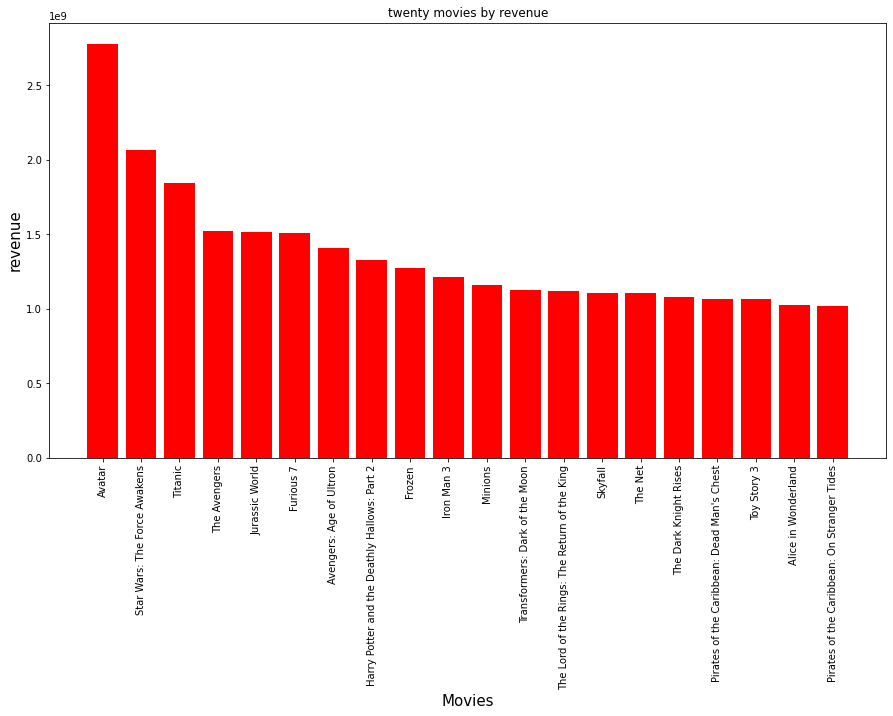

```python
#plotting a histogram of movies vs revenue

#Size (width and height)of the figure
plt.figure(figsize=(15,8))
plt.bar( "original_title","revenue", data = data, color = 'red')
plt.title('twenty movies by revenue')
plt.xlabel('Movies', fontsize = 15)
plt.xticks(rotation = 90)
plt.ylabel('revenue', fontsize = 15)


plt.show()
```

The heighest earning movies here have made at 1,000,000,000.00USD. A majority of the movies were released after the year 2010.

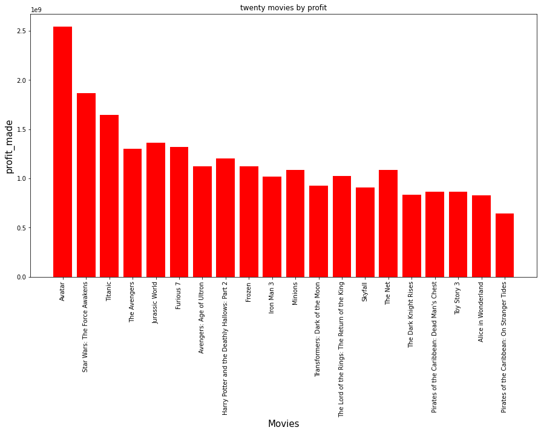

```python
#plotting a histogram of movies vs profit

#Size (width and height)of the figure
plt.figure(figsize=(15,8))
plt.bar( "original_title","profit_made", data = data, color = 'red')
plt.title('twenty movies by profit')
plt.xlabel('Movies', fontsize = 15)
plt.xticks(rotation = 90)
plt.ylabel('profit_made', fontsize = 15)


plt.show()
```

The movies by profit graph shows that while movies like 'Avatar', 'Star Wars: The Force Awakens', and 'Titanic' remain in their positions in the top twenty when comparing revenue to profit. 'The Avengers' and 'Iron Man 3' show lower profits when comapred to 'Jurassic World' and 'Minions' respectively.

> **QUESTION 3a: What is the runtime of the top twenty movies**

```python
#only Display the runtime and name of each movie. (from highest runtime to lowest runtime.)
data[['runtime','original_title']]
runtime_order = data[['runtime','original_title']]
runtime_order.sort_values(by=['runtime'],ascending = False)
```

|  | runtime | original_title |
| --- | --- | --- |
| 4949 | 201 | The Lord of the Rings: The Return of the King |
| 5231 | 194 | Titanic |
| 4363 | 165 | The Dark Knight Rises |
| 1386 | 162 | Avatar |
| 3522 | 154 | Transformers: Dark of the Moon |
| 6555 | 151 | Pirates of the Caribbean: Dead Man's Chest |
| 4361 | 143 | The Avengers |
| 4365 | 143 | Skyfall |
| 14 | 141 | Avengers: Age of Ultron |
| 4 | 137 | Furious 7 |
| 3375 | 136 | Pirates of the Caribbean: On Stranger Tides |
| 3 | 136 | Star Wars: The Force Awakens |
| 5425 | 130 | Iron Man 3 |
| 3374 | 130 | Harry Potter and the Deathly Hallows: Part 2 |
| 0 | 124 | Jurassic World |
| 8094 | 114 | The Net |
| 1921 | 108 | Alice in Wonderland |
| 1930 | 103 | Toy Story 3 |
| 5422 | 102 | Frozen |
| 8 | 91 | Minions |

> **QUESTION 3b: What is the average runtime of the movies**

```python
#Calculate average runtime for movies
runtime_order['runtime'].mean()
```

```
138.25
```

```python
#Get information from runtime data.
runtime_order['runtime'].describe()
```

```
count     20.000000
mean     138.250000
std       28.499077
min       91.000000
25%      121.500000
50%      136.500000
75%      151.750000
max      201.000000
Name: runtime, dtype: float64
```

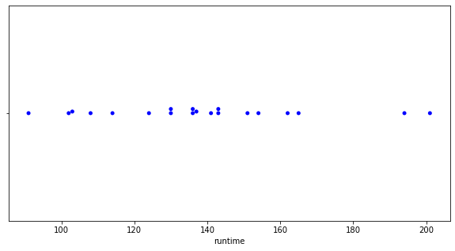

```python
#Plotting runtime of movies and generate the plot with seaborn

plt.figure(figsize=(10,5))
#using seaborn to generate the plot

sns.swarmplot(runtime_order['runtime'], color = 'blue')
plt.show()
```

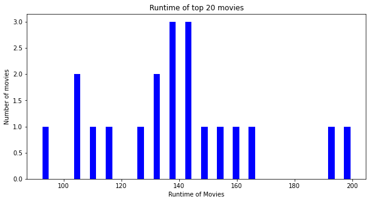

```python
plt.figure(figsize=(10,5))
#A histogram plot of the average.
plt.xlabel('Runtime of Movies')
plt.ylabel('Number of movies')
plt.title('Runtime of top 20 movies')
plt.hist(runtime_order['runtime'], color = 'blue', rwidth = 0.4, bins= 20)
plt.show()
```

> Looking at the above calculation, description and plot, we see the plot visually reflect the overall average of 138,25
> 1. 25% of these movies have a runtime of about 120 minutes.
> 2. 50% of these movies have a runtime of about 136 minutes.
> 3. 75% of these movies have a runtime of about 151 minutes.

> **QUESTION 4: What is the popular genre in the top 20 movies?**

```python
#Defining a funtion to separate the genre column.
def film(column):
    film = data[column].str.cat(sep = '|') #this allows for the column to be separated by the character '|'.
    film = pd.Series(film.split('|')) #I now store the values separately using pandas series.
    film_order = film.value_counts(ascending = False) #Arrange in descending order.

    return film_order
```

```python
data_genres = film('genres')
data_genres
```

```
Adventure          15
Action             14
Science Fiction     7
Fantasy             7
Thriller            6
Family              5
Drama               3
Animation           3
Crime               3
Comedy              2
Mystery             1
Romance             1
dtype: int64
```

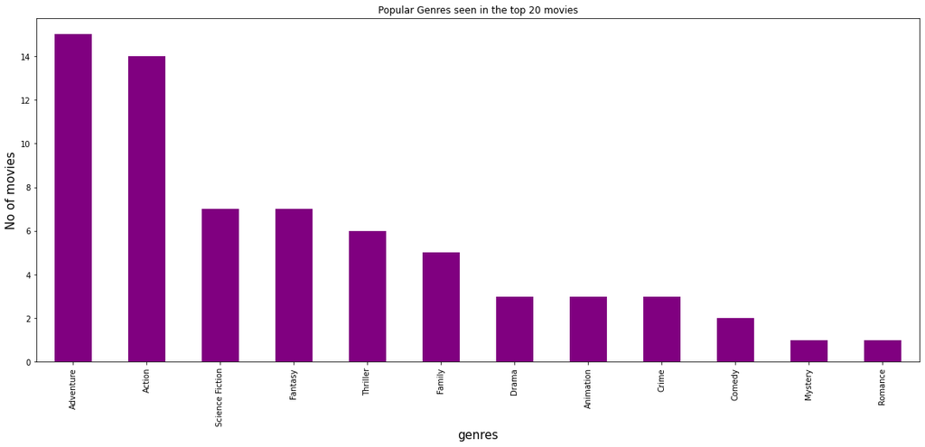

```python
#Visualising the results


#Size (width and height)of the figure
plt.figure(figsize=(20,8))
genre_bar = data_genres.plot.bar(color='purple')
plt.title('Popular Genres seen in the top 20 movies')
plt.xlabel('genres', fontsize = 15)
plt.xticks(rotation = 90)
plt.ylabel('No of movies', fontsize = 15)


plt.show()
```

The above graph shows that the heighest earning movies were mostly adventure and action, showing up on 15 and 14 entries respectively. On the other end of the spectrum, romance, mystery and comedy are the least popular genres in the top twenty

## Limitations

Other limitations are my inability to successfully run a stacked barplot without showing errors to visually display the relationship between revenue and profit of the top 20 movies.